# Compare the ZooScat DWBA to an analytical solution

Sven Gastauer

4th of May 2018

This document compares the results of the the DWBA implementation in ZooScat to an anlytical scattering model of a sphere (Anderson 1950), following routines described in Jech et al. (2015).

This vignette requires the ZooScat package for the implementation of the DWBA model, ggplot2 for plotting, viridis for nicer colors.

```r
library(ZooScat)
library(ggplot2)
library(viridis)
```

## The analytical model of a sphere

For the purpose of this example we will build the general anlytical model for a scattered wave by a sphere (Anderson 1950):
$$p_{scat}=p_0\sum^{\infty}_{n=0}A_n(2n+1)P_n (cos\theta)h^1_n (k_w r)$$
with

- the range ($r$ in [m])
- the acoustic wavenumber in the surrounding water($k_w$)
- $k=\frac{2\pi}{\lambda}$
- wavelength $\lambda=\frac{f}{c}$ in [m]
- $f$ is the frequency in $Hz =s^{-1}$
- $c$ is the soundspeed in $\frac{m}{s}$)
- $p_0$ is the incident pressure
- $A_n$ is defined by the boundary conditions (Anderson 1950). For $A_n$, definitions following (Jech et al. 2015) were used, rather than (Anderson 1950).
- $P_n$ is the Legendre polynomial with degree $n$
- $h^1_n$ is the spherical Hankel function of the first kind or the spherical Bessel function of thrid the kind
- $\theta$ is the scattering angle

For backscatter $\theta=\pi$; therefore $P_n$ becomes $P_n(-1)=(-1)^n$.

In the farfield $k_wr 1, h^1_n(k_wr) e^{ik_wr} $ the acoustic backscatter pressure $p_{bs}$ can be expressed as a function of backscattering amplitude ($f_{bs}$, incident pressure, phase and range:
$$p_{bs}=p_0 \frac{e^{ik_w r}}{r}f_{bs}$$
with the simplified $f_bs$ becoming:
$$f_{bs}=-\frac{i}{k_w}\sum^{\infty}_{n=0}(-1)^n(2n+1)A_n$$
following Jech et al. (2015), $n$ was limited to the nearest integer of $||k_wa||+20$, providing a precision of 0.1 dB.

From $f_bs$, target strength $TS$ in $dB \text{ re }m^2$ can be computed as (Anderson 1950):
$$TS = 10log_{10}(|f_bs|^2)$$

For a fluid filled sphere, the coefficient, the coefficient $A_n$ can be computed as:
$$A_n=\frac{-1}{1+iC_n}$$
and
$$C_n = \frac{\frac{[j'_n(k_1a)y_n(ka)]}{[j_n(k_1a)j'_n(ka)]} - gh\frac{y'_n(ka)}{j'_n(ka)}}{\frac{[j'_n(k_1a)j_n(ka)]}{[j_n(k_1a)j'_n(ka)]}-gh}$$
with:

- $k_1$ the wavenumber inside the fluid-filled sphere
- $g$ the density contrast for the density $[\frac{kg}{m^3}]$ inside the sphere ($\rho_t) and in the surrounding fluid ($_w$)
- $h$ the soundspeed contrast for the soundspped $[\frac{m}{s}]$ inside the sphere ($c_t) and in the surrounding fluid ($c_w$)
- $y$ is the spherical Neumann function

Letting $gh \rightarrow \infty$ results in a rigid sphere and:
$$A_n=-\frac{j'_n(k_wa)}{h'_n(k_wa)}$$
Similarly, letting $gh \rightarrow 0$ results in a pressure release sphere and:
$$A_n=-\frac{j_n(k_wa)}{h_n(k_wa)}$$

These functions have been implemented within ZooScat and can be called using:

```r
r <- 10 #range
a <- 0.01 # radius
c <- 1477.4 #soundspeed surrounding fluid
rho <- 1026.8 #density surrounding fluid
g <- 1028.9/rho #density contrast
h <- 1480.3/c #soundspeed contrast
f <- 200 * 1000 #Frequency in Hz
TS.sphere2(f=f,r=r,a=a,c=c,h=h,g=g,rho=rho)
```

```
## [1] -106.721
```

Note: Results involving Bessel functions have to be used with a bit of caution. Given the diffrent ways available to compute the Bessel functions slight variations occur for example between results obtained in Matlab and R. Generally the fluctuations are relatively small (within a fraction of 1%), but they are noticeable.

### Settings for a weakly scattering sphere

The following settings were used for a weakly scattering sphere, as defined in (Jech et al. 2015):

```r
r <- 10 #range
a <- 0.01 # radius
c <- 1477.4 #soundspeed surrounding fluid
rho <- 1026.8 #density surrounding fluid
g <- 1028.9/rho #density contrast
h <- 1480.3/c #soundspeed contrast

#Frequency range
fmin=12
fmax=400
freqs <- seq(fmin,fmax, by=0.5)
```

Set the settings inside ZooScat:

```r
fname <- paste0(system.file(package="ZooScat"),"/extdata/configs/config_0.dat") #Loacation of the parameters file
para = read_para(fname) #Read parameters file

#Create list with soundspeed info
misc <- list(cw=c) #Set soundspeed in the surrounding fluid

#Set the material properties
para$phy$g0 <- g #set the density contrast
para$phy$h0 <- h #set the soundspeed contrast

#set the simulation parameters
para$simu$var0<-fmin #Set the minimum frequency
para$simu$var1<-fmax #Set the maximum frequency
para$simu$n=length(freqs) #Set the number of output points
para$simu$ni=2000 #any high number
```

## Building a sphere inside ZooScat

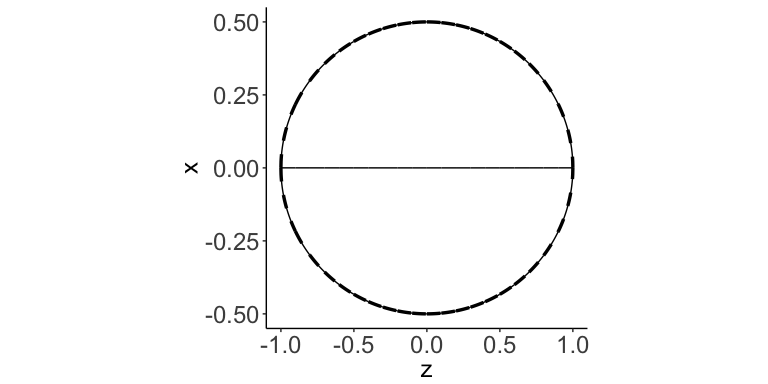

```r
#Set the shape parameters
para$shape$L <- 2*1000*a # 2 * the radius in m to get length in mm
para$shape$order <- 2 #Set the tapering order
para$shape$L_a <- 2 #Set L/a
para$shape$rho_L <- 2000 #any high number to get a high curvature

#Build the sphere and plot the result
sp <- buildpos(para) #build the shape
sp$plot #show the shape plot
```

## Run the different models

Run the analytical model:

```r
fs <- as.list(freqs*1000) #Create a list of frequencies
TS.MJ <- sapply(fs,TS.sphere2,r=r,a=a,c=c,h=h,g=g,rho=rho) #Apply frequency list to the analytical model
```

Run the ZooScat DWBA:

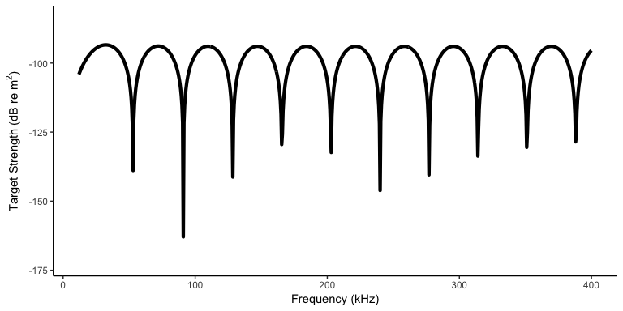

```r
#Run DWBA based on config file
DWBA <- bscat(para=para, misc=misc)
#Show the model outcome
DWBA$rplot
```

Build a function to compute and plot the error:
The error is computed following Jech et al. (2015) as:
$$|\overline{\Delta TS}|=\frac{1}{N}\sum^N_{i=1}|TS_{i. predicted}-TS_{i-benchmark}|$$
with $N$ the number of sample points (frequency points).

```r
# Compare results
TS.comp <- function(TS1, TS2, freqs) {
    require(ggplot2)
    require(viridis)
    TScomp <- as.data.frame(cbind(TS = c(TS1, TS2), Freq = rep(freqs, 2), Model = rep(c("Analytical",
        "DWBA"), each = length(freqs))))
    names(TScomp) <- c("TS", "Frequency", "Model")
    TScomp$TS <- as.numeric(as.character(TScomp$TS))
    TScomp$Frequency <- as.numeric(as.character(TScomp$Frequency))

    err <- sum(abs(TS1 - TS2))/length(freqs)
    TScomp$diff <- rep(abs(TS1 - TS2), 2)
    message(paste("Overall error:", round(mean(err), 2), "dB"))
    # ggplot remove backgorund
    rmb <- theme(axis.line = element_line(colour = "black"), panel.grid.major = element_blank(),
        panel.grid.minor = element_blank(), panel.border = element_blank(),
        panel.background = element_blank())

    print(ggplot(data = TScomp, aes(x = Frequency, y = TS, group = Model, col = Model)) +
        geom_line(lwd = 1) + scale_color_brewer(palette = "Set1") + theme(legend.position = "top") +
        xlab("Frequency [kHz]") + rmb)
    print(ggplot(data = TScomp, aes(x = Frequency, y = diff, col = diff)) +
        geom_line(lwd = 1.2) + scale_color_viridis(name = "dB difference") +
        theme(legend.position = "top") + xlab("Frequency [kHz]") + rmb)
    return(TScomp)
}
```

Run the error function for the anylitcal and modelled solutions:

```r
TS.compare <- TS.comp(TS.MJ,DWBA$y,freqs)
```

```
## Overall error: 0.25 dB
```

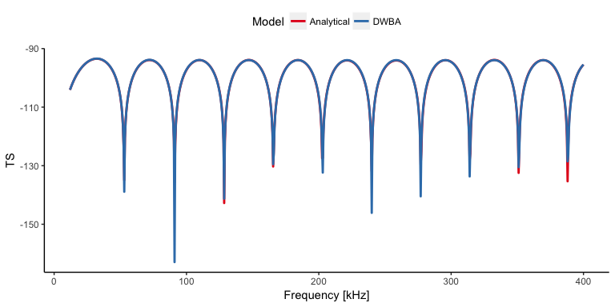

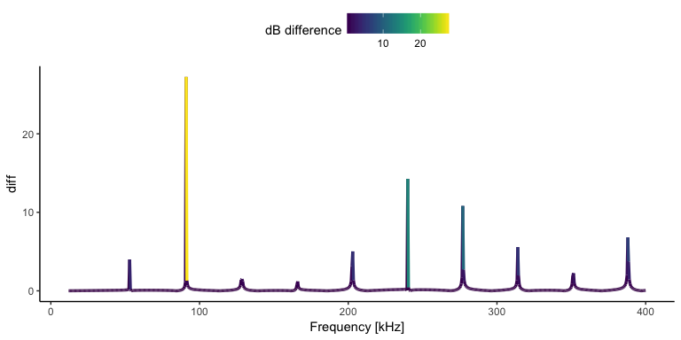

For a weak scattering sphere, the error is mostly below 1%. Only within the null locations, the error increases, while th elocations of the nulls are good.

```r
a <- 0.01
g <- 1.0357 #density contrast
h <- 1.0279 #soundspeed contrast
c <- 1456

#Set the material properties in ZooScat
para$shape$L <- 2*1000*a # 2 * the radius in m to get length in mm
para$phy$g0 <- g #set the density contrast
para$phy$h0 <- h #set the soundspeed contrast
misc$cw <- c

#Run the analytical model
TS.MJ <- sapply(fs,TS.sphere2,r=r,a=a,c=c,h=h,g=g,rho=rho) #Apply frequency list to the analytical model

#Run the ZooScat DWBA:
DWBA <- bscat(para=para, misc=misc)
```

Compare the results:

```r
TS.compare <- TS.comp(TS.MJ,DWBA$y,freqs)
```

```
## Overall error: 1.97 dB
```

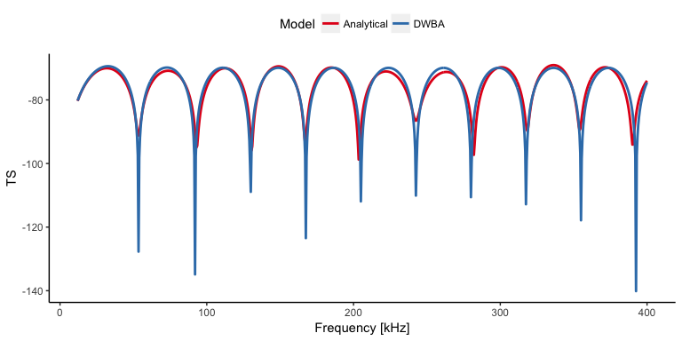

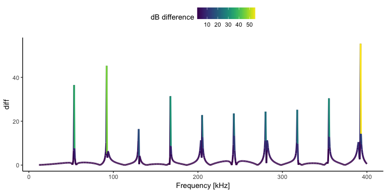

The ZooScat DWBA model performs well for the material preperties of krill, when compared to the analytical model.

```r
a <- 0.0381
g <- 14900/rho #density contrast
h <- 6853/c #soundspeed contrast

#Set the material properties in ZooScat
para$shape$L <- 2*1000*a # 2 * the radius in m to get length in mm
para$phy$g0 <- g #set the density contrast
para$phy$h0 <- h #set the soundspeed contrast

#Run the analytical model
TS.MJ <- sapply(fs,TS.sphere2,r=r,a=a,c=c,h=h,g=g,rho=rho) #Apply frequency list to the analytical model

#Run the ZooScat DWBA:
DWBA <- bscat(para=para, misc=misc)
```

Compare the results:

```r
TS.compare <- TS.comp(TS.MJ,DWBA$y,freqs)
```

```
## Overall error: 21.57 dB
```

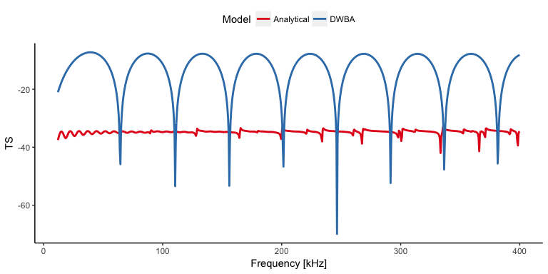

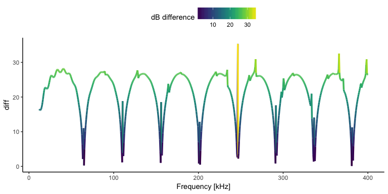

The ZooScat DWBA model holds no validity for such strong scatterers. ##References

Anderson, Victor C. 1950. “Sound Scattering from a Fluid Sphere.” *The Journal of the Acoustical Society of America* 22 (4): 426–31.

Calise, L., and G. Skaret. 2011. “Sensitivity Investigation of the SDWBA Antarctic Krill Target Strength Model to Fatness, Material Contrasts and Orientation.” *Ccamlr Science* 18: 97–122.

Jech, J. Michael, John K. Horne, Dezhang Chu, David A. Demer, David TI Francis, Natalia Gorska, Benjamin Jones, Andone C. Lavery, Timothy K. Stanton, and Gavin J. Macaulay. 2015. “Comparisons Among Ten Models of Acoustic Backscattering Used in Aquatic Ecosystem Research.” *The Journal of the Acoustical Society of America* 138 (6): 3742–64.